# Clarke et al. (2022): the fitted model

In the foraging task of Clarke, Irons, James, Leber & Hunt (2022, *QJEP*), 58 people selected all 40 targets on each trial, 20 of each of two types, in a **feature** and a **conjunction** condition. As in other foraging studies, people tend to collect one target type in long runs in conjunction foraging, and switch more freely in feature foraging. The paper’s abstract says 64 people were tested; the data have 58 (exclusions, still to be confirmed). With 87,760 selections it is the largest dataset here.

This page shows how to work with a fitted model: checking convergence, reading the posterior, accuracy and posterior predictive checks. The model is the default one: multi-level, Fourier-124 directions, the default priors, 4 chains of 1000 warmup and 1000 sampling iterations.

Code: `clarke2022qjep.R`.

```r
source("../../../functions/set_up_FoMo.R")
```

```
[1] "set_up_FoMo.R: random seed set to 65 (FOMO_SEED)"
```

```r
source("../fit_models/fit_settings.R")

# the fit this page reads (made by ../fit_models/fit_models.R)
require_example_fits("clarke2022qjep_fourier124")

n_post_draws <- 5    # posterior draws for the posterior predictive check
```

## 1 The data

```r
d <- import_data("clarke2022qjep")

d$stim |>
  summarise(people = n_distinct(person), trials = n_distinct(trial),
            items_per_trial = n() / n_distinct(trial), .by = condition) |>
  left_join(summarise(d$found, selections = n(), .by = condition), by = "condition") |>
  knitr::kable()
```

| condition | people | trials | items_per_trial | selections |
| --- | --- | --- | --- | --- |
| feature | 58 | 1134 | 40 | 45360 |
| conjunction | 58 | 1060 | 40 | 42400 |

One random trial from each condition. Items are coloured by target type; the line is the order the targets were selected in.

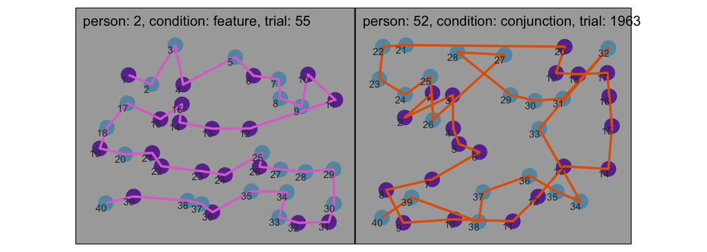

Figure 1: One trial per condition: items and selection order.

```r
plot_trial(d$found, d$stim)
```

How long people kept selecting the same target type before switching (runs): the main difference between the conditions.

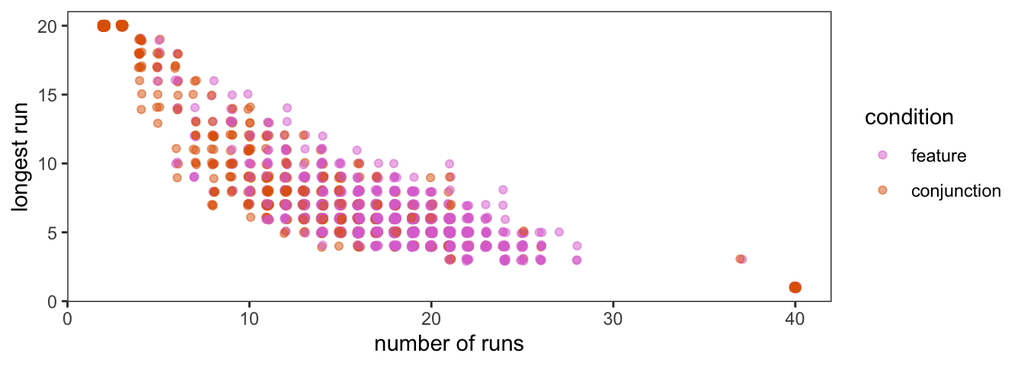

Figure 2: Run lengths by condition.

```r
plot_runs(compute_runs(d$found))
```

Per-trial statistics, used below to check the fitted model against the data.

```r
trial_stats <- compute_trial_stats(d$found)
head(trial_stats) |> knitr::kable(digits = 2)
```

| person | condition | n_found | best_r | mean_itd | pao | n_runs | max_run_length |
| --- | --- | --- | --- | --- | --- | --- | --- |
| 1 | feature | 40 | 0.81 | 0.15 | 12.0 | 20.2 | 5.25 |
| 1 | conjunction | 40 | 0.40 | 0.21 | 56.5 | 2.9 | 19.20 |
| 2 | feature | 40 | 0.94 | 0.15 | 15.9 | 19.5 | 5.55 |
| 2 | conjunction | 40 | 0.79 | 0.17 | 28.1 | 12.2 | 9.30 |
| 3 | feature | 40 | 0.85 | 0.17 | 28.4 | 14.8 | 7.16 |
| 3 | conjunction | 40 | 0.38 | 0.22 | 66.1 | 2.2 | 20.00 |

## 2 The fit

```r
# the fit, and the data list it was made from (fit_fomo() stores it with the fit)
fit <- read_example_fit("clarke2022qjep", "fourier124")
sl <- attr(fit, "fomo_sl")
```

Population-level estimates (medians and 97% HPDIs) and convergence. R-hat and ESS are coloured green (good), orange (acceptable) or red (bad). At 1000 iterations this fit’s largest R-hat is 1.02 and its smallest bulk ESS about 200: fine for a walkthrough, but a published analysis should use 2000.

```r
fomo_summary(fit, cond_labels = levels(d$stim$condition))
```

**Fixed effects (median and 97% HPDI)**

| parameter | condition | component | lower | median | upper | rhat | ess_bulk | ess_tail |
| --- | --- | --- | --- | --- | --- | --- | --- | --- |
| rho_delta | feature |  | 2.33 | 2.49 | 2.65 | 1.00 | 5674 | 2896 |
| rho_delta | conjunction |  | 1.62 | 1.70 | 1.79 | 1.00 | 5373 | 2903 |
| rho_psi | feature |  | -1.45 | -1.21 | -1.00 | 1.00 | 632 | 1153 |
| rho_psi | conjunction |  | -1.00 | -0.82 | -0.62 | 1.00 | 816 | 1463 |
| fourier_coef | feature | h1 cos | -0.33 | -0.17 | -0.04 | 1.02 | 205 | 622 |
| fourier_coef | conjunction | h1 cos | -0.07 | 0.01 | 0.09 | 1.01 | 487 | 1107 |
| fourier_coef | feature | h1 sin | 0.33 | 0.53 | 0.73 | 1.02 | 217 | 502 |
| fourier_coef | conjunction | h1 sin | 0.26 | 0.38 | 0.50 | 1.00 | 367 | 725 |
| fourier_coef | feature | h2 cos | 0.15 | 0.25 | 0.35 | 1.01 | 301 | 813 |
| fourier_coef | conjunction | h2 cos | 0.26 | 0.34 | 0.45 | 1.02 | 291 | 603 |
| fourier_coef | feature | h2 sin | 0.00 | 0.05 | 0.10 | 1.00 | 1061 | 1809 |
| fourier_coef | conjunction | h2 sin | 0.03 | 0.07 | 0.10 | 1.00 | 2322 | 2715 |
| fourier_coef | feature | h4 cos | 0.18 | 0.24 | 0.28 | 1.01 | 698 | 1783 |
| fourier_coef | conjunction | h4 cos | 0.19 | 0.24 | 0.29 | 1.01 | 745 | 1307 |
| fourier_coef | feature | h4 sin | -0.01 | 0.02 | 0.04 | 1.00 | 5831 | 3030 |
| fourier_coef | conjunction | h4 sin | -0.01 | 0.02 | 0.05 | 1.00 | 4099 | 2962 |
| b_v_logodds | feature | 1,1 | 0.48 | 0.74 | 1.01 | 1.00 | 6285 | 2864 |
| b_v_logodds | conjunction | 1,1 | 2.83 | 4.03 | 5.22 | 1.00 | 5554 | 2674 |
| b_v_logodds | feature | 2,1 | -1.14 | -0.89 | -0.60 | 1.00 | 5649 | 2936 |
| b_v_logodds | conjunction | 2,1 | -4.14 | -3.13 | -2.10 | 1.00 | 4733 | 2812 |
| b_v | feature | 1,1 | 0.62 | 0.68 | 0.74 | 1.00 | 6285 | 2864 |
| b_v | conjunction | 1,1 | 0.95 | 0.98 | 1.00 | 1.00 | 5554 | 2674 |
| b_v | feature | 2,1 | 0.24 | 0.29 | 0.35 | 1.00 | 5649 | 2936 |
| b_v | conjunction | 2,1 | 0.01 | 0.04 | 0.10 | 1.00 | 4733 | 2812 |
| b_v | feature | 1,2 | 0.26 | 0.32 | 0.38 | 1.00 | 6285 | 2864 |
| b_v | conjunction | 1,2 | 0.00 | 0.02 | 0.05 | 1.00 | 5554 | 2674 |
| b_v | feature | 2,2 | 0.65 | 0.71 | 0.76 | 1.00 | 5649 | 2936 |
| b_v | conjunction | 2,2 | 0.90 | 0.96 | 0.99 | 1.00 | 4733 | 2812 |

Convergence (all parameters): largest R-hat 1.019 (sigma_u_fourier_coef[1,2]); smallest bulk ESS 205 (fourier_coef[1,1]), tail ESS 502 (fourier_coef[1,2]); 0 divergent transitions.

Rank plots of the five worst-mixing parameters. If the chains have mixed well, each chain’s histogram is roughly flat and they overlap.

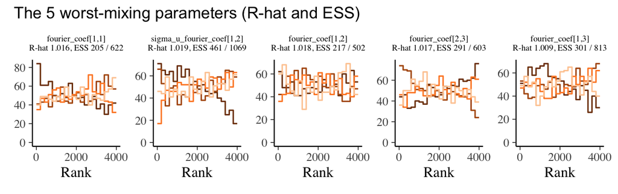

```r
plot_post_traces(fit)
```

## 3 Posterior

`extract_post()` turns the fit’s draws into tidy tables (one per group of parameters), which the `plot_post_*()` functions take.

```r
post <- extract_post(fit, d$found, d$stim)
```

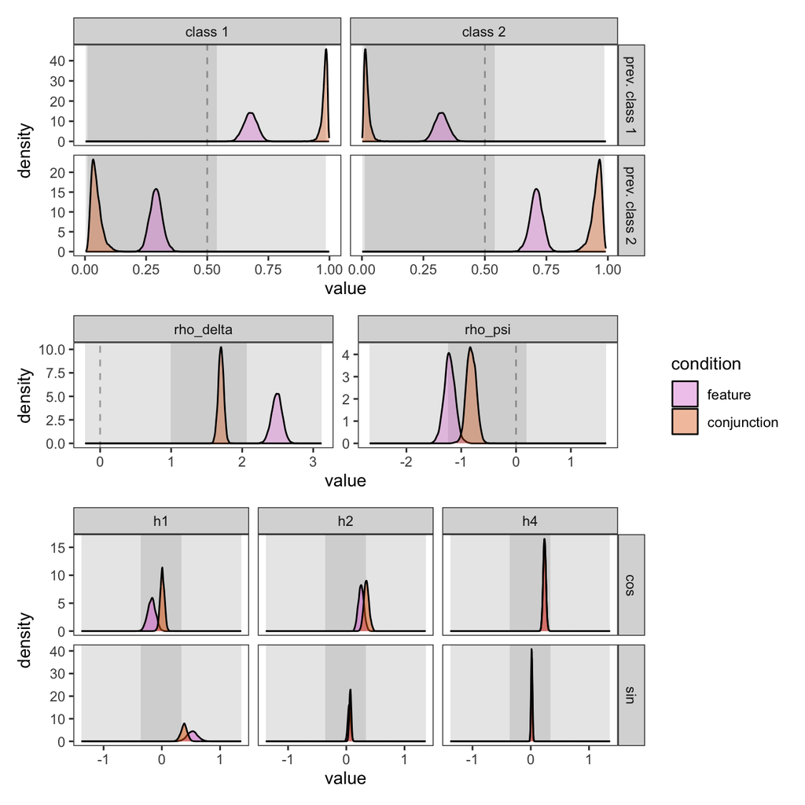

Figure 4: Posterior densities by condition: class transitions, distance and relative direction, and the Fourier coefficients. Grey bands: the priors’ HPDIs.

```r
plot_post(post)
```

The same spatial parameters, shown as what each does to an item’s selection weight:

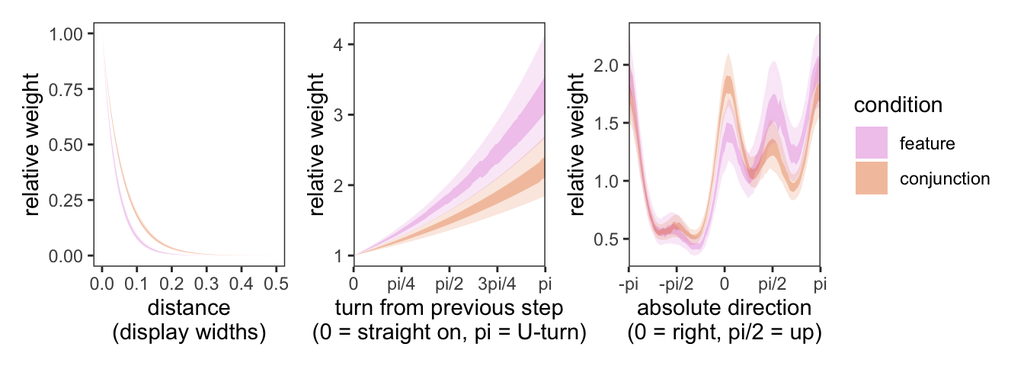

Figure 5: Relative selection weight against distance, turn and absolute direction: 53% and 97% HPDIs.

```r
plot_post_spatial(post, show = "weights")
```

Each person’s distance and relative-direction estimates, over the population’s:

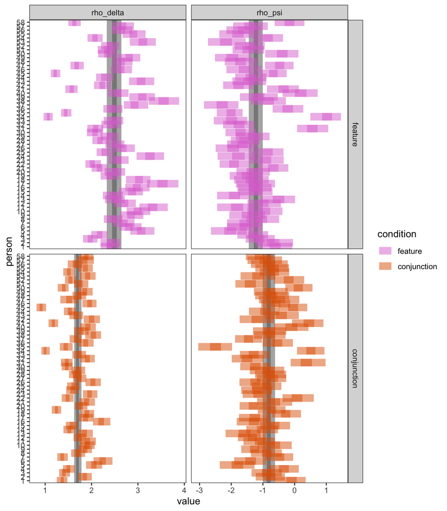

Figure 6: Per-person estimates (intervals) over the population-level HPDIs (grey bands).

```r
plot_post_per_person_spatial(post)
```

And each person’s class-transition probabilities: how likely they are to select each target type next, given the type they just selected. With two types each row of the matrix sums to one, so the columns come in mirrored pairs.

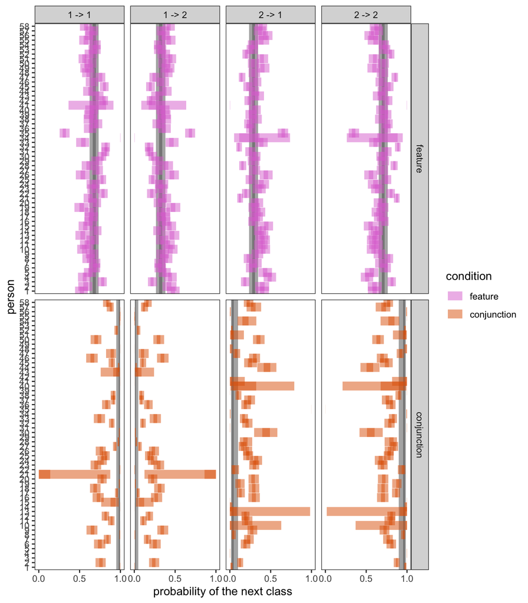

Figure 7: Per-person class-transition probabilities (previous type -> next type) over the population-level HPDIs (grey bands).

```r
plot_post_per_person_cat(post)
```

## 4 Accuracy

The fit doesn’t store a prediction for every selection (`save_selections = FALSE`, the default), so `predict_fomo()` makes them from 200 posterior draws. Deterministic accuracy is how often the item the model judges most likely is the one selected; the probability of the chosen item credits being nearly right too. Chance (dotted) is 1 / items left; the nearest-neighbour rule (dashed) always picks the closest item, so the gap above it is what the model adds to proximity alone. This is in-sample accuracy, which overestimates out-of-sample accuracy.

```r
# the fit doesn't store per-selection predictions (save_selections =
# FALSE), so predict them for a subset of draws
pred <- predict_fomo(fit, sl, n_draws = 200)
acc <- extract_post(pred, d$found, d$stim)$acc
```

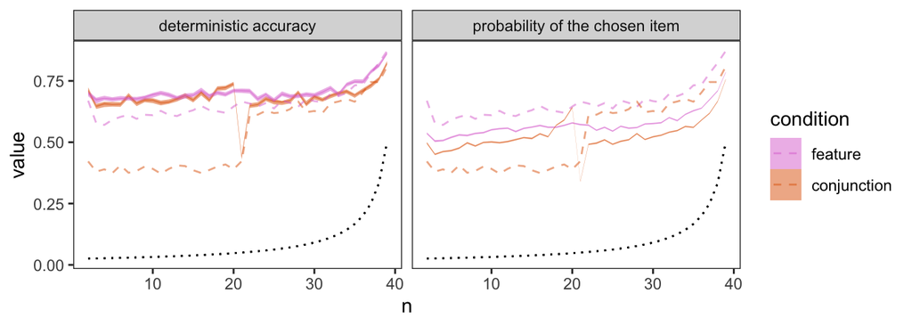

Figure 8: Accuracy at each selection, with chance and nearest-neighbour baselines.

```r
plot_post_accuracy(acc, d$stim, d$found)
```

## 5 Posterior predictive check

Whole trials simulated from the fitted model (5 posterior draws: the dataset is large), compared with the data. The model doesn’t predict when a trial stops, so each simulated trial keeps as many selections as the observed one.

```r
# whole trials simulated from the fit; the model doesn't predict when a
# trial stops, so keep as many simulated selections as the data have
sim_post <- sim_fomo(sl, fit, iter = n_post_draws)
extract_pred(sim_post, d$stim) |>
  semi_join(d$found, by = c("trial", "n")) -> found_post
```

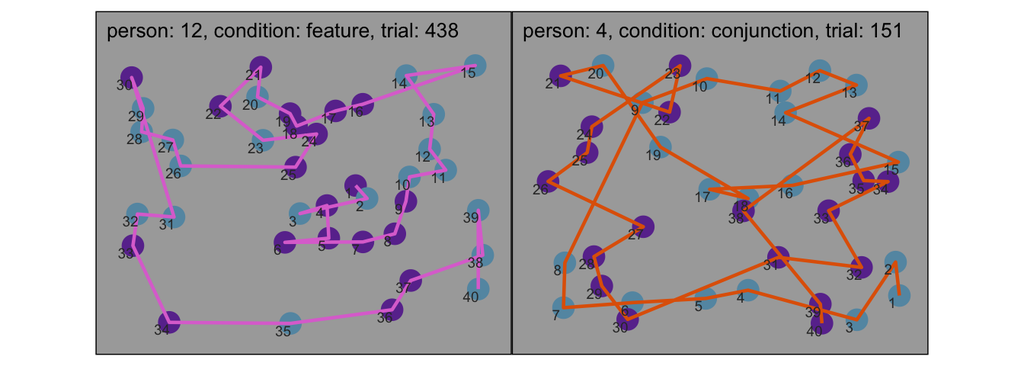

Figure 9: One trial per condition, simulated from the fitted model.

```r
plot_trial(found_post, d$stim)
```

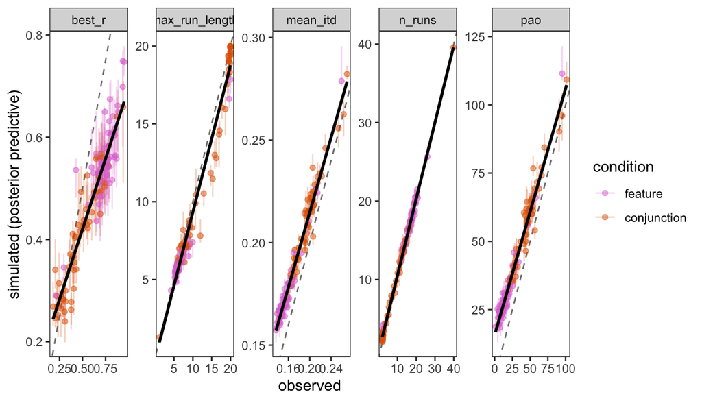

Figure 10: Trial statistics for the data (x) and simulated from the posterior (y). Points near the diagonal mean the model reproduces them.

```r
sim_stats <- compute_trial_stats(found_post)
plot_trial_stats(trial_stats, sim_stats)
```